# Python analysis lab - Answers

- Load in the dataset, calling it `drinks_content`, and then briefly explore it, printing out: first 5 rows, last 5 rows, and then all of the data. Find out the dimensions of the data (number of rows and columns) and the column names.

```python
import pandas as pd
import numpy as np
import matplotlib.pyplot as plt
```

```python
drinks_content = pd.read_csv("starbucks_drinkMenu_expanded.csv")
# First 5 rows
drinks_content.head()

# Last 5 rows
```

```
##          Beverage_category       Beverage  ... Iron (% DV)   Caffeine (mg)
## 0                   Coffee  Brewed Coffee  ...           0%            175
## 1                   Coffee  Brewed Coffee  ...           0%            260
## 2                   Coffee  Brewed Coffee  ...           0%            330
## 3                   Coffee  Brewed Coffee  ...           0%            410
## 4  Classic Espresso Drinks    Caffè Latte  ...           0%             75
##
## [5 rows x 18 columns]
```

```python
drinks_content.tail()

# Print everything
```

```
##               Beverage_category  ... Caffeine (mg)
## 237  Frappuccino® Blended Crème  ...             0
## 238  Frappuccino® Blended Crème  ...             0
## 239  Frappuccino® Blended Crème  ...             0
## 240  Frappuccino® Blended Crème  ...             0
## 241  Frappuccino® Blended Crème  ...             0
##
## [5 rows x 18 columns]
```

```python
drinks_content

# Dimensions
```

```
##                      Beverage_category  ... Caffeine (mg)
## 0                               Coffee  ...           175
## 1                               Coffee  ...           260
## 2                               Coffee  ...           330
## 3                               Coffee  ...           410
## 4              Classic Espresso Drinks  ...            75
## 5              Classic Espresso Drinks  ...            75
## 6              Classic Espresso Drinks  ...            75
## 7              Classic Espresso Drinks  ...            75
## 8              Classic Espresso Drinks  ...            75
## 9              Classic Espresso Drinks  ...            75
## 10             Classic Espresso Drinks  ...           150
## 11             Classic Espresso Drinks  ...           150
## 12             Classic Espresso Drinks  ...           150
## 13             Classic Espresso Drinks  ...           150
```

[output cut: 49 more lines]

```python
drinks_content.shape

# Column names
```

```
## (242, 18)
```

```python
drinks_content.columns
```

```
## Index(['Beverage_category', 'Beverage', 'Beverage_prep', 'Calories',
##        ' Total Fat (g)', 'Trans Fat (g) ', 'Saturated Fat (g)', ' Sodium (mg)',
##        ' Total Carbohydrates (g) ', 'Cholesterol (mg)', ' Dietary Fibre (g)',
##        ' Sugars (g)', ' Protein (g) ', 'Vitamin A (% DV) ', 'Vitamin C (% DV)',
##        ' Calcium (% DV) ', 'Iron (% DV) ', 'Caffeine (mg)'],
##       dtype='object')
```

- We’re going to be looking at the number of `Calories` in each drink. Calculate some quick summary statistics to check the mean, the variance, and the normality of this variable (i.e. plot a histogram).

```python
# Check the mean
drinks_content["Calories"].mean()

# Check the variance
```

```
## 193.87190082644628
```

```python
drinks_content["Calories"].var()

# Histogram
```

```
## 10580.85904118514
```

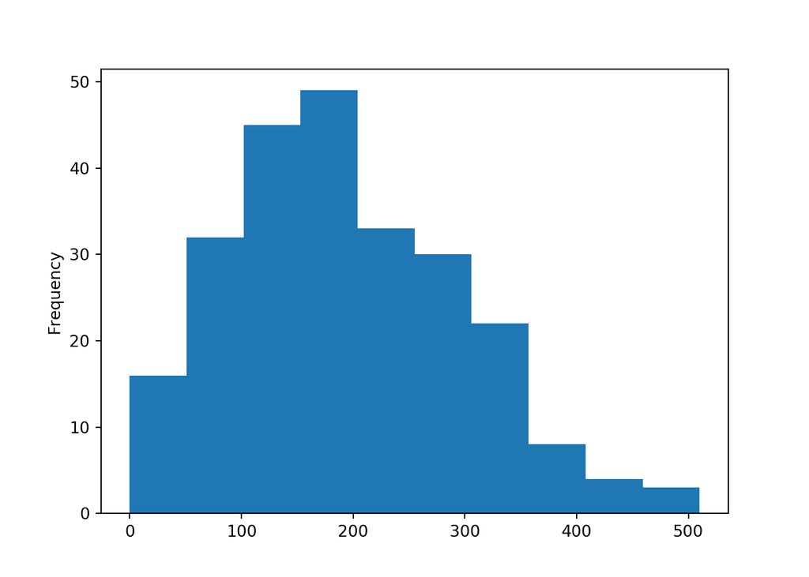

```python
drinks_content["Calories"].plot(kind = "hist")
plt.show()
```

- Check if you have any outliers in the `Calories` variable by creating a boxplot. (There is no need to change or remove any outliers you find)

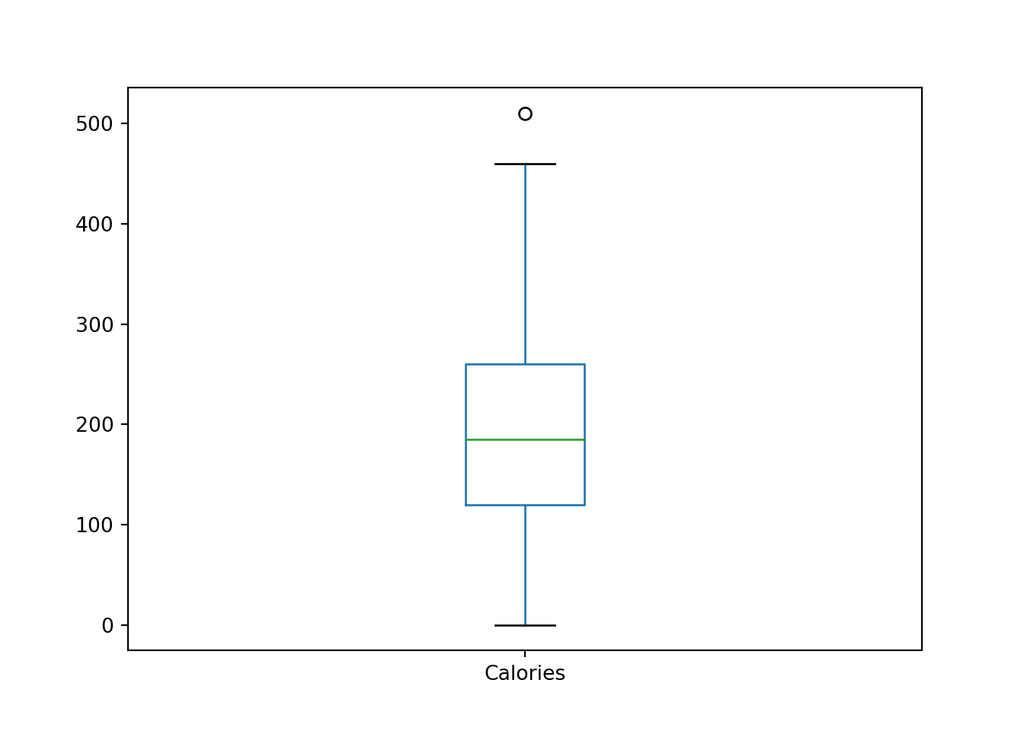

```python
# Create a boxplot
drinks_content["Calories"].plot(kind = "box")
plt.show()
```

- Select the variables `Beverage_category`, `Beverage`, `Beverage prep` and `Calories` from the `drinks_content` data frame, and assign the selected columns to a new data frame called `drinks`. Check if there are any `NaN` values anywhere in the data, and drop any rows containing them.

```python
# Select dataset with specific columns
drinks = drinks_content[["Beverage", "Beverage_category", "Beverage_prep", "Calories"]]

# Check if there are NA values
drinks.isna().sum()

# There shouldn't be any, but if there are:
```

```
## Beverage             0
## Beverage_category    0
## Beverage_prep        0
## Calories             0
## dtype: int64
```

```python
drinks.dropna(inplace = True)
```

- Filter the data so we only take “Classic Espresso Drinks”, and save this in a new data frame called `espresso_drinks`.

```python
# Filter out espresso drinks
espresso_drinks = drinks[drinks["Beverage_category"] == "Classic Espresso Drinks"]
espresso_drinks
```

```
##                                     Beverage  ... Calories
## 4                                Caffè Latte  ...       70
## 5                                Caffè Latte  ...      100
## 6                                Caffè Latte  ...       70
## 7                                Caffè Latte  ...      100
## 8                                Caffè Latte  ...      150
## 9                                Caffè Latte  ...      110
## 10                               Caffè Latte  ...      130
## 11                               Caffè Latte  ...      190
## 12                               Caffè Latte  ...      150
## 13                               Caffè Latte  ...      170
## 14                               Caffè Latte  ...      240
## 15                               Caffè Latte  ...      190
## 16       Caffè Mocha (Without Whipped Cream)  ...      110
## 17       Caffè Mocha (Without Whipped Cream)  ...      130
```

[output cut: 46 more lines]

- Group your `espresso_drinks` data frame by the type of beverage prep, and then find out the mean calories for each drink group.

```python
espresso_drinks.groupby("Beverage_prep").mean()
```

```
##                     Calories
## Beverage_prep
## 2% Milk              184.375
## Doppio                10.000
## Grande                15.000
## Grande Nonfat Milk   150.000
## Short                  5.000
## Short Nonfat Milk     78.000
## Solo                   5.000
## Soymilk              151.250
## Tall                  10.000
## Tall Nonfat Milk     116.000
## Venti                 25.000
## Venti Nonfat Milk    194.000
```

- Get the same grouped mean `Calories` values as above, but this time sorted in descending order.

```python
espresso_drinks.groupby("Beverage_prep").mean().sort_values(by = "Calories", ascending = False)
```

```
##                     Calories
## Beverage_prep
## Venti Nonfat Milk    194.000
## 2% Milk              184.375
## Soymilk              151.250
## Grande Nonfat Milk   150.000
## Tall Nonfat Milk     116.000
## Short Nonfat Milk     78.000
## Venti                 25.000
## Grande                15.000
## Doppio                10.000
## Tall                  10.000
## Short                  5.000
## Solo                   5.000
```